# **Panorama da inflação**

Os principais índices de inflação do Brasil, apontam em agosto de 2009 um recuo da inflação de em média **-0.04%**. Com esse resultado, no ano a inflação acumula uma variação média positiva de **1.48%**, e em 12 meses uma variação média acumulada de **2.70%**.

|  | Variação mensal | Variação acumulada no ano | Variação acumulada em 12 meses |
| --- | --- | --- | --- |
| IPCA | 0.15% | 2.97% | 4.36% |
| INPC | 0.08% | 3.07% | 4.44% |
| IGP-M | -0.36% | -1.59% | -0.71% |
| IGP-DI | 0.09% | -1.6% | -0.53% |
| IPA | 0.07% | -0.04% | -0.03% |
| IPC | 0.2% | 2.37% | 4.73% |
| INCC | -0.05% | 2.29% | 5.1% |

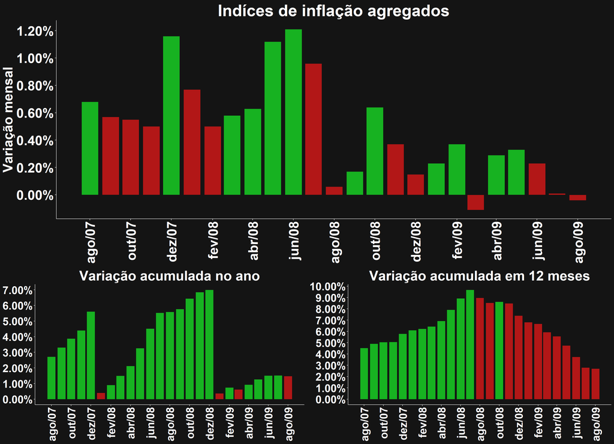

Índices selecionados para a média: IPCA, INPC e IGP-M.

# IPCA

|  | 08/2008 | 07/2009 | 08/2009 |
| --- | --- | --- | --- |
| Variação mensal | 0.28% | 0.24% | 0.15% |
| Variação acumulada no ano | 4.48% | 2.81% | 2.97% |
| Variação acumulada em 12 meses | 6.17% | 4.5% | 4.36% |

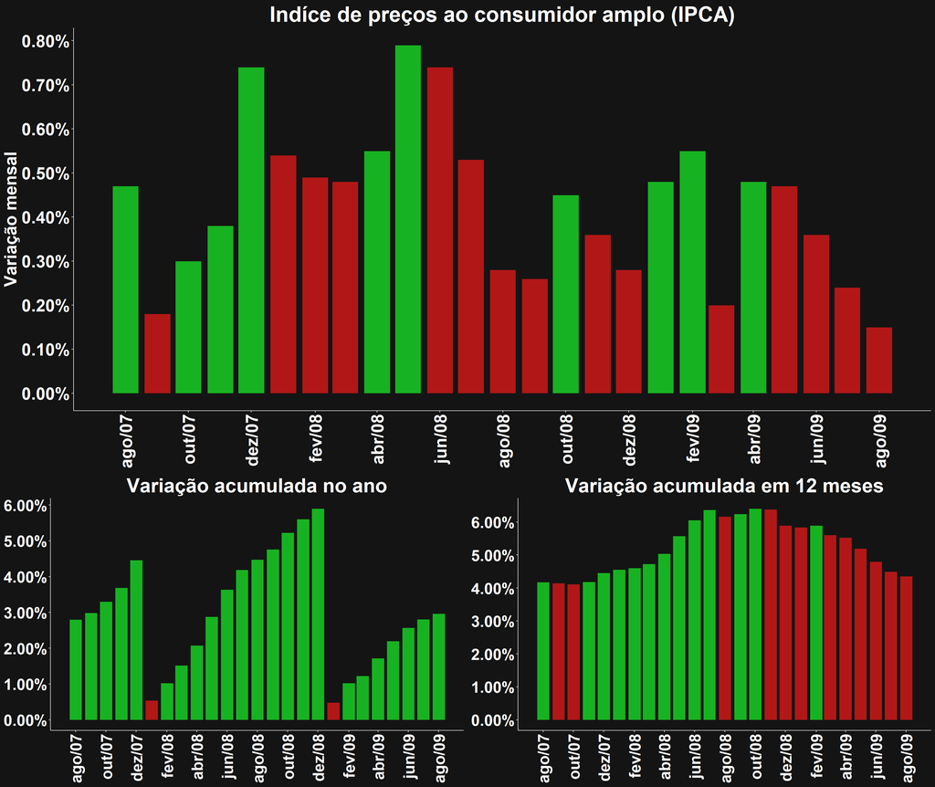

Os grupos que tiveram maior resultado positivo foram Educação (0.83%) e Habitação (0.47%), e negativo Artigos de residência (-0.24%) e Transportes (-0.11%).

|  | Variação mensal | Variação acumulada no ano | Peso mensal |
| --- | --- | --- | --- |
| Alimentação e bebidas | -0.01% | 2.57% | 22.72% |
| Habitação | 0.47% | 4.36% | 13.29% |
| Artigos de residência | -0.24% | 1.74% | 4.21% |
| Vestuário | 0.13% | 3.44% | 6.66% |
| Transportes | -0.11% | 0.18% | 19.2% |
| Saúde e cuidados pessoais | 0.21% | 4.24% | 10.88% |
| Despesas pessoais | 0.27% | 6.18% | 10.16% |
| Educação | 0.83% | 5.88% | 7.09% |
| Comunicação | -0.02% | 0.04% | 5.79% |

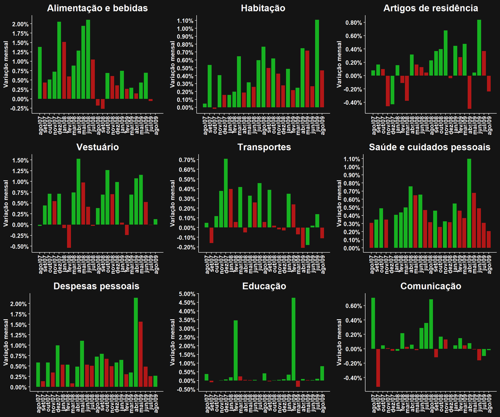

A nível de sub-itens os que mais influenciaram positivamente no resultado em relação ao seu peso foram Refeição (0.86%%) e Ensino superior (1.42%%), e negativamente Leite pasteurizado (-6.61%%) e Passagem aérea (-10.97%%).

|  | Variação mensal | Variação acumulada no ano | Peso mensal |
| --- | --- | --- | --- |
| Tomate | 14.96% | -15.5% | 0.16% |
| Ensino superior | 1.42% | 3.25% | 2.12% |
| Refeição | 0.86% | 6.1% | 4.23% |
| Plano de saúde | 0.55% | 4.1% | 3.41% |

|  | Variação mensal | Variação acumulada no ano | Peso mensal |
| --- | --- | --- | --- |
| Automóvel usado | -1.55% | -11.64% | 1.28% |
| Passagem aérea | -10.97% | -16.15% | 0.27% |
| Móvel para quarto | -3.1% | 7.06% | 0.5% |
| Leite pasteurizado | -6.61% | 25.2% | 1.31% |

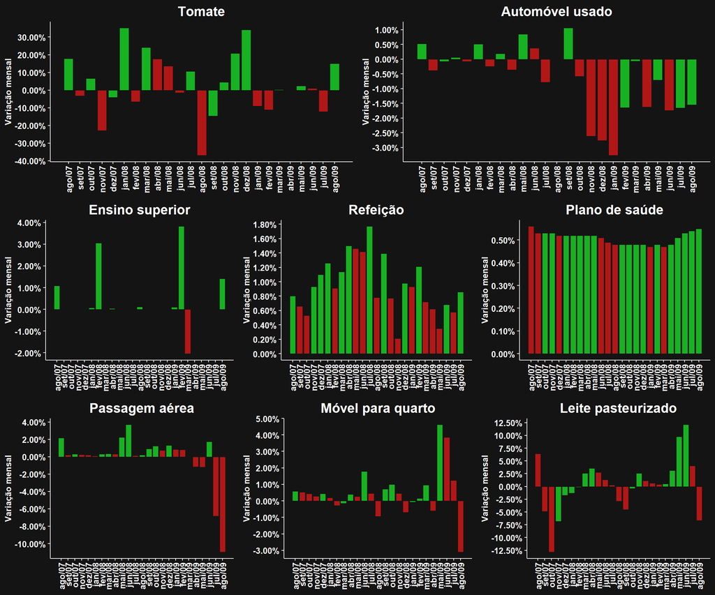

# INPC

|  | 08/2008 | 07/2009 | 08/2009 |
| --- | --- | --- | --- |
| Variação mensal | 0.21% | 0.23% | 0.08% |
| Variação acumulada no ano | 5.09% | 2.99% | 3.07% |
| Variação acumulada em 12 meses | 7.15% | 4.57% | 4.44% |

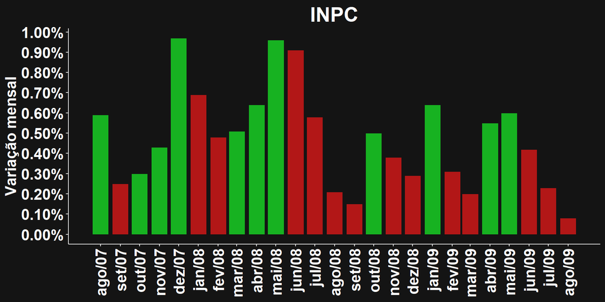

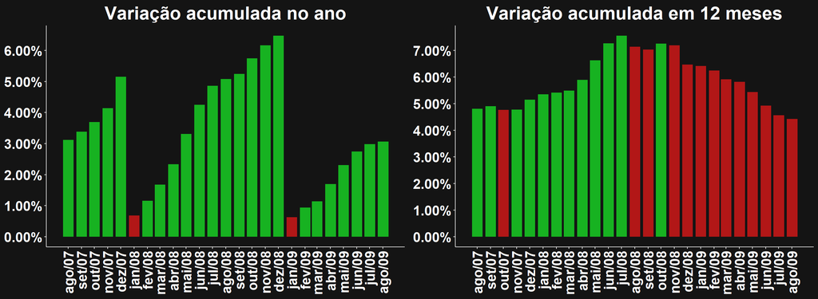

# IGP-M

O Indíce Geral de Preços de Mercado (IGP-M) variou -0.36% em agosto, valor inferior ao mesmo período do ano anterior quando apresentou uma taxa de -0.32%. Com esse resultado o indíce acumula no ano uma variação negativa de -1.59%, e em 12 meses uma variação negativa de -0.71%.

|  | 08/2008 | 07/2009 | 08/2009 |
| --- | --- | --- | --- |
| Variação mensal | -0.32% | -0.43% | -0.36% |
| Variação acumulada no ano | 7.19% | -1.24% | -1.59% |
| Variação acumulada em 12 meses | 13.63% | -0.67% | -0.71% |

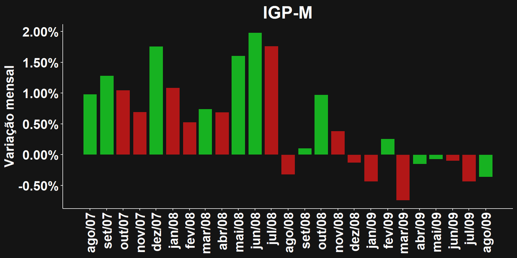

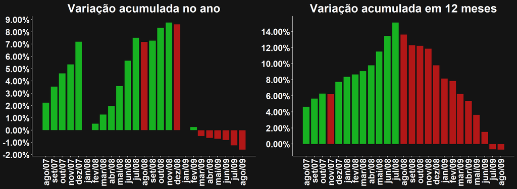

# IGP-DI

O Indíce Geral de Preços - Disponibilidade Interna (IGP-DI) variou 0.09% em agosto, valor superior ao mesmo período do ano anterior quando apresentou uma taxa de -0.38%. Com esse resultado o indíce acumula no ano uma variação negativa de -1.6%, e em 12 meses uma variação negativa de -0.53%.

|  | 08/2008 | 07/2009 | 08/2009 |
| --- | --- | --- | --- |
| Variação mensal | -0.38% | -0.64% | 0.09% |
| Variação acumulada no ano | 6.88% | -1.69% | -1.6% |
| Variação acumulada em 12 meses | 12.8% | -1% | -0.53% |

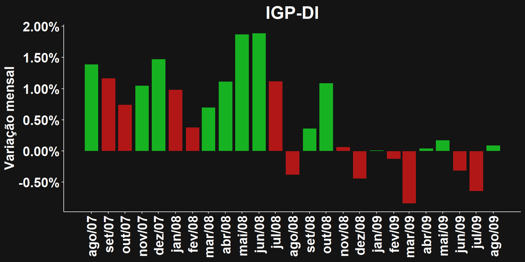

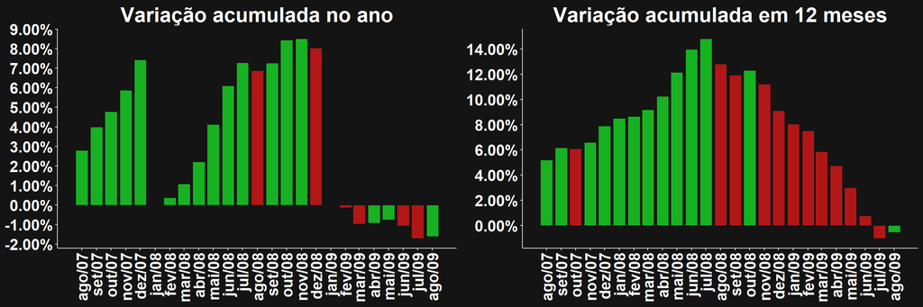

O Indíce de Preços de Atacado (IPA), integrante do IGP-DI com peso de 60%, apresentou variação de 0.07% em agosto, valor superior ao mesmo período do ano anterior quando apresentou uma taxa de -0.8%. Com esse resultado o indíce acumula no ano uma variação negativa de -0.04%, e em 12 meses uma variação negativa de -0.03%.

|  | 08/2008 | 07/2009 | 08/2009 |
| --- | --- | --- | --- |
| Variação mensal | -0.8% | -1.16% | 0.07% |
| Variação acumulada no ano | 0.09% | -0.04% | -0.04% |
| Variação acumulada em 12 meses | 0.16% | -0.04% | -0.03% |

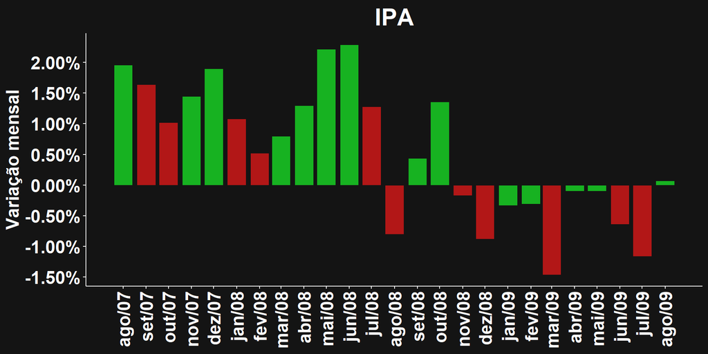

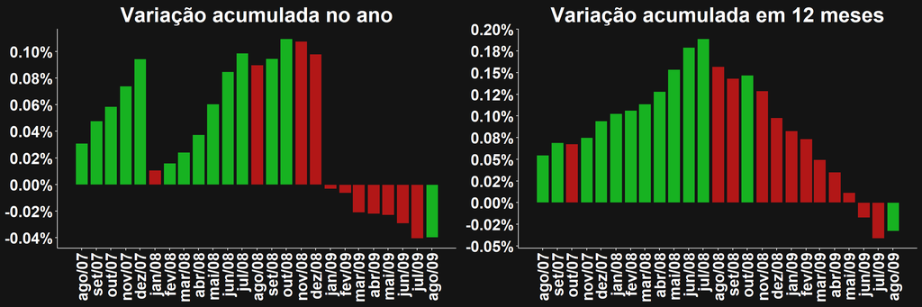

O Indíce de Preços ao Consumidor (IPC), integrante do IGP-DI com peso de 30%, apresentou variação de 0.2% em agosto, valor superior ao mesmo período do ano anterior quando apresentou uma taxa de 0.14%. Com esse resultado o indíce acumula no ano uma variação positiva de 2.37%, e em 12 meses uma variação positiva de 4.73%.

|  | 08/2008 | 07/2009 | 08/2009 |
| --- | --- | --- | --- |
| Variação mensal | 0.14% | 0.34% | 0.2% |
| Variação acumulada no ano | 3.53% | 2.16% | 2.37% |
| Variação acumulada em 12 meses | 5.93% | 4.67% | 4.73% |

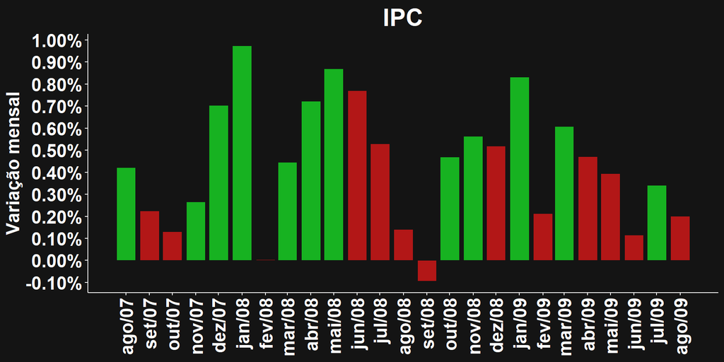

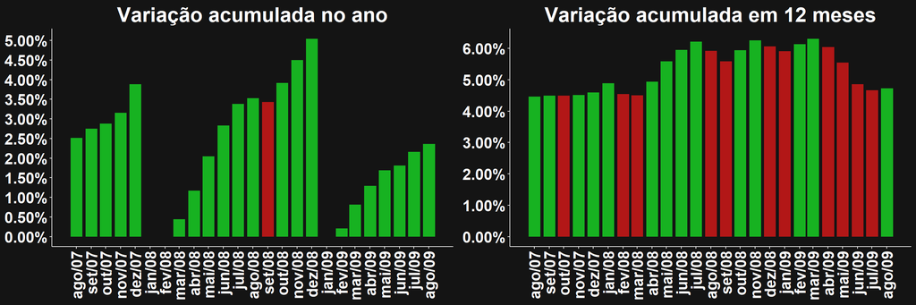

O Indíce Nacional de Custos de Construção (INCC), integrante do IGP-DI com peso de 10%, apresentou variação de -0.05% em agosto, valor inferior ao mesmo período do ano anterior quando apresentou uma taxa de 1.18%. Com esse resultado o indíce acumula no ano uma variação positiva de 2.29%, e em 12 meses uma variação positiva de 5.1%.

|  | 08/2008 | 07/2009 | 08/2009 |
| --- | --- | --- | --- |
| Variação mensal | 1.18% | 0.26% | -0.05% |
| Variação acumulada no ano | 8.83% | 2.34% | 2.29% |
| Variação acumulada em 12 meses | 11.4% | 6.4% | 5.1% |

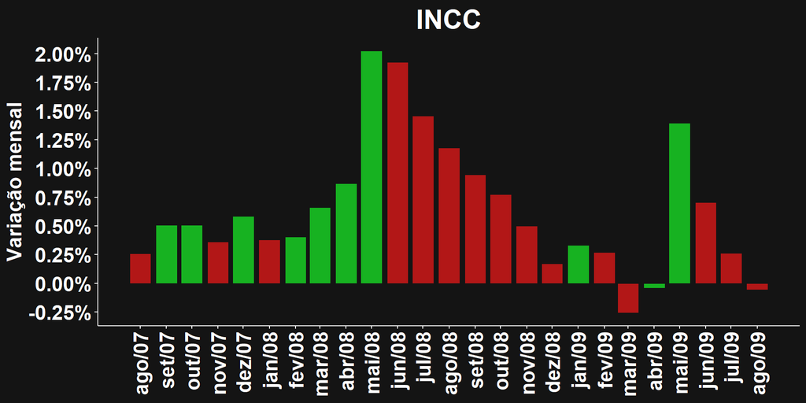

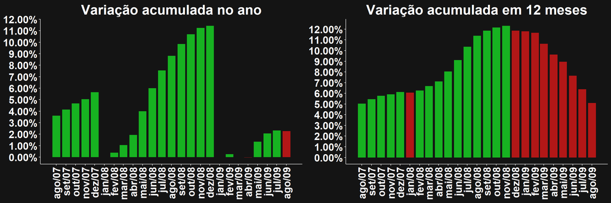

# Estatísticas

As estatísticas descritivas a seguir são feitas com base nos últimos 48 meses, e tem como objetivo possibilitar a avaliação do resultado observado em comparação aos períodos anteriores.

|  | Minimo | 1 Quartil | Mediana | Media | 3 Quartil | Maximo | Desvio Padrão |
| --- | --- | --- | --- | --- | --- | --- | --- |
| IPCA | -0.21% | 0.26% | 0.36% | 0.38% | 0.48% | 0.79% | 0.19% |
| INPC | -0.07% | 0.23% | 0.39% | 0.39% | 0.54% | 0.97% | 0.23% |
| IGP-M | -0.74% | -0.02% | 0.33% | 0.4% | 0.74% | 1.98% | 0.63% |
| IGP-DI | -0.84% | 0.06% | 0.3% | 0.41% | 0.73% | 1.89% | 0.6% |
| IPA | -1.46% | -0.12% | 0.26% | 0.4% | 1.03% | 2.29% | 0.86% |
| IPC | -0.4% | 0.19% | 0.34% | 0.36% | 0.54% | 0.97% | 0.28% |
| INCC | -0.26% | 0.24% | 0.37% | 0.54% | 0.72% | 2.02% | 0.48% |

Levando em consideração o desvio padrão de cada indíce, proporcionalmente os que mais se afastaram da média foram o INPC, o INCC e o IPCA.

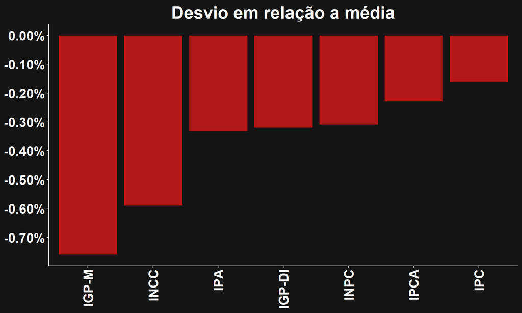

**João Victor Gomes**  
**jvg.santana@gmail.com**  
**[linkedin.com/in/jvictorgomes](https://www.linkedin.com/in/jvictorgomes/)**